# Naive_Bayes_Project

```python
import pandas as pd
import os
import matplotlib.pyplot as plt
%matplotlib inline
import seaborn as sns
plt.style.use('ggplot')
from sklearn import preprocessing
from sklearn.preprocessing import LabelEncoder
from sklearn.preprocessing import scale
import os
import pandas as pd
#import pandas_profiling
import statsmodels.formula.api as smf
from statsmodels.api import add_constant
import statsmodels.api as sm
#from sklearn.cross_validation import train_test_split as tts
import matplotlib.pyplot as plt
import scipy.stats as stats
from datetime import datetime
import seaborn as sns
import numpy as np
from statsmodels.stats.outliers_influence import variance_inflation_factor
from patsy import dmatrices
from sklearn import metrics
from sklearn.linear_model import LinearRegression
from scipy import stats
import pylab
#from sklearn.cross_validation import cross_val_score
from sklearn.model_selection import cross_val_predict
from sklearn.neighbors import KNeighborsClassifier as KNC
from sklearn.metrics import roc_curve,auc
from sklearn.neighbors import KNeighborsRegressor as KNR
from sklearn.preprocessing import LabelEncoder as LE
#import sklearn.cross_validation
from xgboost import XGBClassifier
from sklearn.neural_network import MLPClassifier

from sklearn.metrics import accuracy_score
from sklearn.metrics import precision_score
from sklearn.metrics import recall_score
from sklearn.metrics import roc_auc_score
from sklearn.metrics import f1_score

from sklearn import preprocessing

#from xgboost import plot_importance
import numpy as np
from sklearn.metrics import confusion_matrix
from sklearn.linear_model import LogisticRegression

from sklearn.preprocessing import StandardScaler
from sklearn.preprocessing import MinMaxScaler
from itertools import combinations
from sklearn.preprocessing import PolynomialFeatures
from sklearn.feature_selection import RFE
from sklearn.feature_selection import SelectKBest, chi2,f_classif
from sklearn.feature_selection import SelectFromModel
#from sklearn.cross_validation import cross_val_score
from collections import Counter
from imblearn.pipeline import make_pipeline as make_pipeline_imb
from imblearn.over_sampling import SMOTE
from imblearn.metrics import classification_report_imbalanced
from sklearn.pipeline import make_pipeline

from sklearn.model_selection import train_test_split as tts
from sklearn.model_selection import cross_val_score
from sklearn.feature_selection import SelectKBest
from sklearn.feature_selection import chi2
from sklearn.feature_selection import VarianceThreshold

from sklearn.naive_bayes import GaussianNB
```

```python
pima_Data=pd.read_csv('pima.csv')
```

```python
pima_Data.columns
```

```
Index(['Preg', 'Plas', 'Pres', 'skin', 'test', 'mass', 'pedi', 'age', 'y'], dtype='object')
```

```python
pima_Data.head()
```

|  | Preg | Plas | Pres | skin | test | mass | pedi | age | y |
| --- | --- | --- | --- | --- | --- | --- | --- | --- | --- |
| 0 | 6 | 148 | 72 | 35 | 0 | 33.6 | 0.627 | 50 | 1 |
| 1 | 1 | 85 | 66 | 29 | 0 | 26.6 | 0.351 | 31 | 0 |
| 2 | 8 | 183 | 64 | 0 | 0 | 23.3 | 0.672 | 32 | 1 |
| 3 | 1 | 89 | 66 | 23 | 94 | 28.1 | 0.167 | 21 | 0 |
| 4 | 0 | 137 | 40 | 35 | 168 | 43.1 | 2.288 | 33 | 1 |

```python
pima_Data.where?
```

```python
pima_Data.shape
```

```
(768, 9)
```

```python
pima_Data[pima_Data.test==0].shape[0]
```

```
374
```

```python
var=pima_Data.columns
```

```python
for i in var:
    print(i,'has',pima_Data[pima_Data[i]==0].shape[0]/768,'percent of 0')
```

```
Preg has 0.14453125 percent of 0
Plas has 0.006510416666666667 percent of 0
Pres has 0.045572916666666664 percent of 0
skin has 0.2955729166666667 percent of 0
test has 0.4869791666666667 percent of 0
mass has 0.014322916666666666 percent of 0
pedi has 0.0 percent of 0
age has 0.0 percent of 0
y has 0.6510416666666666 percent of 0
```

```python
pima_Data.Preg.unique()
```

```
array([ 6,  1,  8,  0,  5,  3, 10,  2,  4,  7,  9, 11, 13, 15, 17, 12, 14])
```

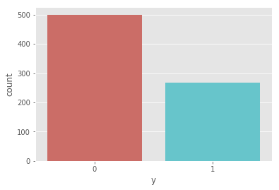

```python
sns.countplot(x='y',data=pima_Data, palette='hls')
plt.show()
```

```python
pima_Data.groupby('y').mean()
```

| y | Preg | Plas | Pres | skin | test | mass | pedi | age |
| --- | --- | --- | --- | --- | --- | --- | --- | --- |
| 0 | 3.298000 | 109.980000 | 68.184000 | 19.664000 | 68.792000 | 30.304200 | 0.429734 | 31.190000 |
| 1 | 4.865672 | 141.257463 | 70.824627 | 22.164179 | 100.335821 | 35.142537 | 0.550500 | 37.067164 |

```python
for i in var:
    print(i,'has',pima_Data[i][pima_Data[i]!=0].median(),'Median')
```

```
Preg has 4.0 Median
Plas has 117.0 Median
Pres has 72.0 Median
skin has 29.0 Median
test has 125.0 Median
mass has 32.3 Median
pedi has 0.3725 Median
age has 29.0 Median
y has 1.0 Median
```

```python
var
```

```
Index(['Preg', 'Plas', 'Pres', 'skin', 'test', 'mass', 'pedi', 'age', 'y'], dtype='object')
```

```python
var1=var[1:8]
```

```python
var1
```

```
Index(['Plas', 'Pres', 'skin', 'test', 'mass', 'pedi', 'age'], dtype='object')
```

```python
for i in var1:
    pima_Data[i][pima_Data[i]==0]=pima_Data[i][pima_Data[i]!=0].median()
```

```python
for i in var:
    print(i,'has',pima_Data[pima_Data[i]==0].shape[0]/768,'percent of 0')
```

```
Preg has 0.14453125 percent of 0
Plas has 0.0 percent of 0
Pres has 0.0 percent of 0
skin has 0.0 percent of 0
test has 0.0 percent of 0
mass has 0.0 percent of 0
pedi has 0.0 percent of 0
age has 0.0 percent of 0
y has 0.6510416666666666 percent of 0
```

```python
pima_Data.groupby('y').mean()
```

| y | Preg | Plas | Pres | skin | test | mass | pedi | age |
| --- | --- | --- | --- | --- | --- | --- | --- | --- |
| 0 | 3.298000 | 110.682000 | 70.920000 | 27.726000 | 127.792000 | 30.885600 | 0.429734 | 31.190000 |
| 1 | 4.865672 | 142.130597 | 75.123134 | 31.686567 | 164.701493 | 35.383582 | 0.550500 | 37.067164 |

Average age of diabetic women of Pima Indian tribe is 37 which is higher than the non diabetic women. Plasma Glucose Concentration, Blood Pressure, Skin Thickness , Insulin level, BMI and pedi are lower understandably for non diabetic.

```python
pima_Data.groupby(['Preg','y']).mean()
```

| Preg | y | Plas | Pres | skin | test | mass | pedi | age |
| --- | --- | --- | --- | --- | --- | --- | --- | --- |
| 0 | 0 | 111.945205 | 73.150685 | 29.397260 | 137.493151 | 33.054795 | 0.457055 | 27.095890 |
|  | 1 | 144.236842 | 74.578947 | 33.000000 | 152.078947 | 39.213158 | 0.643368 | 28.578947 |
| 1 | 0 | 107.566038 | 66.830189 | 26.056604 | 122.056604 | 29.616038 | 0.451679 | 25.254717 |
|  | 1 | 143.793103 | 73.793103 | 34.517241 | 189.931034 | 37.793103 | 0.613759 | 35.103448 |
| 2 | 0 | 105.214286 | 67.083333 | 26.321429 | 120.238095 | 30.448810 | 0.479881 | 25.892857 |
|  | 1 | 135.473684 | 72.842105 | 35.842105 | 190.368421 | 34.578947 | 0.543737 | 32.947368 |
| 3 | 0 | 109.604167 | 68.708333 | 25.375000 | 119.312500 | 29.904167 | 0.358354 | 28.770833 |
|  | 1 | 148.444444 | 70.814815 | 30.000000 | 169.703704 | 32.548148 | 0.563333 | 29.481481 |
| 4 | 0 | 117.555556 | 73.177778 | 26.800000 | 145.133333 | 31.255556 | 0.410511 | 30.066667 |
|  | 1 | 139.913043 | 73.260870 | 28.565217 | 144.173913 | 33.873913 | 0.516478 | 38.086957 |
| 5 | 0 | 111.666667 | 74.666667 | 30.055556 | 126.722222 | 31.997222 | 0.359278 | 39.416667 |
|  | 1 | 136.761905 | 78.857143 | 30.190476 | 152.571429 | 36.780952 | 0.460095 | 38.380952 |
| 6 | 0 | 115.352941 | 72.735294 | 29.794118 | 138.882353 | 30.541176 | 0.433294 | 37.147059 |
|  | 1 | 139.687500 | 72.750000 | 29.875000 | 145.750000 | 31.775000 | 0.421500 | 44.000000 |
| 7 | 0 | 121.000000 | 77.550000 | 29.500000 | 135.000000 | 31.590000 | 0.405500 | 42.500000 |
|  | 1 | 148.800000 | 74.000000 | 31.480000 | 169.040000 | 34.756000 | 0.474120 | 40.000000 |
| 8 | 0 | 106.625000 | 75.312500 | 29.250000 | 116.062500 | 30.693750 | 0.526750 | 49.625000 |
|  | 1 | 150.000000 | 78.363636 | 32.363636 | 212.272727 | 33.672727 | 0.488682 | 42.272727 |
| 9 | 0 | 107.000000 | 70.400000 | 31.100000 | 133.700000 | 28.840000 | 0.311100 | 46.000000 |
|  | 1 | 144.944444 | 82.055556 | 29.722222 | 140.888889 | 33.300000 | 0.683778 | 43.166667 |
| 10 | 0 | 117.571429 | 78.000000 | 29.214286 | 123.285714 | 30.114286 | 0.411071 | 43.357143 |
|  | 1 | 125.600000 | 73.700000 | 31.600000 | 135.900000 | 34.610000 | 0.514500 | 41.700000 |
| 11 | 0 | 113.250000 | 81.000000 | 31.750000 | 125.000000 | 37.125000 | 0.259000 | 40.750000 |
|  | 1 | 134.000000 | 80.571429 | 32.571429 | 138.571429 | 39.385714 | 0.673143 | 46.714286 |
| 12 | 0 | 111.000000 | 80.200000 | 30.400000 | 106.800000 | 30.560000 | 0.301200 | 48.200000 |
|  | 1 | 116.750000 | 71.500000 | 30.250000 | 244.750000 | 34.575000 | 0.623250 | 46.500000 |
| 13 | 0 | 117.200000 | 74.400000 | 33.600000 | 125.000000 | 33.280000 | 0.405600 | 46.800000 |
|  | 1 | 133.800000 | 87.600000 | 30.000000 | 105.800000 | 36.720000 | 0.521000 | 42.200000 |
| 14 | 1 | 137.500000 | 70.000000 | 27.500000 | 154.500000 | 35.100000 | 0.312000 | 42.000000 |
| 15 | 1 | 136.000000 | 70.000000 | 32.000000 | 110.000000 | 37.100000 | 0.153000 | 43.000000 |
| 17 | 1 | 163.000000 | 72.000000 | 41.000000 | 114.000000 | 40.900000 | 0.817000 | 47.000000 |

```
Text(0,0.5,'Frequency of Diabetic')
```

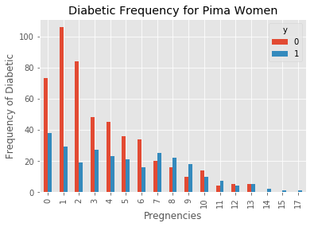

```python
%matplotlib inline
pd.crosstab(pima_Data.Preg,pima_Data.y).plot(kind='bar')
plt.title('Diabetic Frequency for Pima Women')
plt.xlabel('Pregnencies')
plt.ylabel('Frequency of Diabetic')
```

```python
for i in var:
    print(i,'has',pima_Data[i].unique().shape,'unique')
```

```
Preg has (17,) unique
Plas has (135,) unique
Pres has (46,) unique
skin has (50,) unique
test has (185,) unique
mass has (247,) unique
pedi has (517,) unique
age has (52,) unique
y has (2,) unique
```

Pregnency can be a very good predictor of diabetic person

```
Text(0,0.5,'Proportion of Diabetic')
```

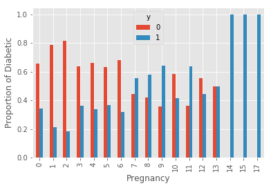

```python
table=pd.crosstab(pima_Data.Preg,pima_Data.y)
table.div(table.sum(1).astype(float), axis=0).plot(kind='bar')
plt.xlabel('Pregnancy')
plt.ylabel('Proportion of Diabetic')
```

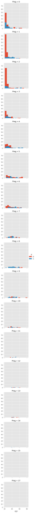

```python
FG=sns.FacetGrid(pima_Data,row='Preg',hue='y')
FG=FG.map(plt.hist,'age')
FG.add_legend()
```

```python
pima_Data.Preg[(pima_Data.Preg==9)& (pima_Data.y==1)].shape[0]
```

```
18
```

```python
pima_Data.Preg[(pima_Data.Preg==1)& (pima_Data.y==1)].shape[0]
```

```
29
```

```python
data_final_vars=data_final.columns.values.tolist()
```

```python
pima_Data.dtypes
```

```
Preg      int64
Plas      int64
Pres      int64
skin      int64
test      int64
mass    float64
pedi    float64
age       int64
y         int64
dtype: object
```

```python
Y_Var=pima_Data[['y']]
X_Var=pima_Data.drop('y',axis=1)
```

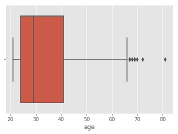

```python
sns.boxplot(X_Var.age)
```

```python
IQR_age=X_Var.age.quantile(.75)-X_Var.age.quantile(.25)
upper_bound=X_Var.age.quantile(.75) + (1.5*IQR_age)
X_Var.age.clip_upper(upper_bound,inplace=True)
```

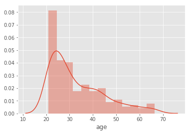

```python
sns.distplot(X_Var.age)
```

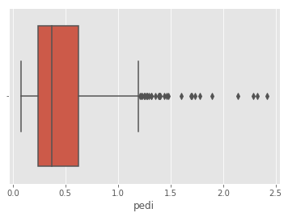

```python
sns.boxplot(X_Var.pedi)
```

```python
IQR_pedi=X_Var.pedi.quantile(.75)-X_Var.pedi.quantile(.25)
upper_bound=X_Var.pedi.quantile(.75) + (1.5*IQR_pedi)
X_Var.pedi.clip_upper(upper_bound,inplace=True)
```

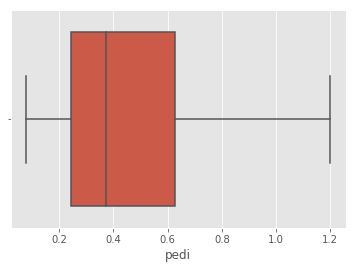

```python
sns.boxplot(X_Var.pedi)
```

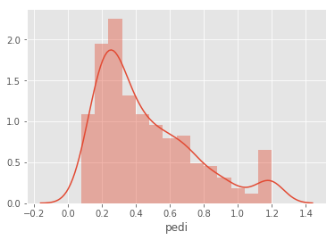

```python
sns.distplot(X_Var.pedi)
```

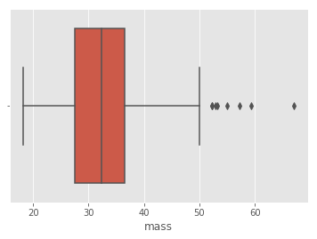

```python
sns.boxplot(X_Var.mass)
```

```python
def upp_outlier(var):
    IQR=X_Var[var].quantile(.75)-X_Var[var].quantile(.25)
    upper_bound=X_Var[var].quantile(.75) + (1.5*IQR)
    return(X_Var[var].clip_upper(upper_bound,inplace=True))
```

```python
upp_outlier('mass')
```

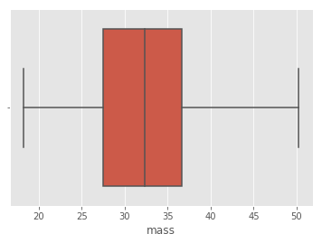

```python
sns.boxplot(X_Var.mass)
```

```python
def low_outlier(var):
    IQR=X_Var[var].quantile(.75)-X_Var[var].quantile(.25)
    upper_bound=X_Var[var].quantile(.25) - (1.5*IQR)
    return(X_Var[var].clip_lower(upper_bound,inplace=True))
```

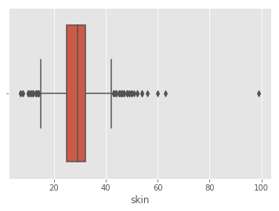

```python
sns.boxplot(X_Var.skin)
```

```python
low_outlier('skin')
upp_outlier('skin')
```

[figure not shown]

```python
sns.boxplot(X_Var.age)
```

```python
upp_outlier('age')
```

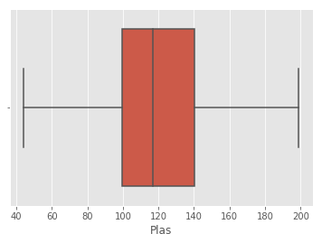

```python
sns.boxplot(X_Var.Plas)
```

```
Range of Plasma Diabetic Women 121
Range of Plasma Non Diabetic Women 153
```

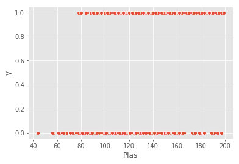

```python
sns.scatterplot(x=X_Var.Plas,y=Y_Var.y)
print('Range of Plasma Diabetic Women', X_Var.Plas[Y_Var.y==1].max()-X_Var.Plas[Y_Var.y==1].min())
print('Range of Plasma Non Diabetic Women', X_Var.Plas[Y_Var.y==0].max()-X_Var.Plas[Y_Var.y==0].min())
```

```
Range of BP Diabetic Women 84
Range of BP Non Diabetic Women 98
```

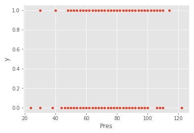

```python
sns.scatterplot(x=X_Var.Pres,y=Y_Var.y)
print('Range of BP Diabetic Women', X_Var.Pres[Y_Var.y==1].max()-X_Var.Pres[Y_Var.y==1].min())
print('Range of BP Non Diabetic Women', X_Var.Pres[Y_Var.y==0].max()-X_Var.Pres[Y_Var.y==0].min())
```

```
Range of skin thickness Diabetic Women 28.0
Range of skin thickness Non Diabetic Women 28.0
```

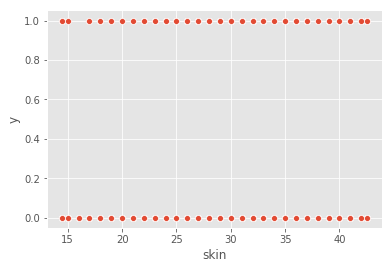

```python
sns.scatterplot(x=X_Var.skin,y=Y_Var.y)
print('Range of skin thickness Diabetic Women', X_Var.skin[Y_Var.y==1].max()-X_Var.skin[Y_Var.y==1].min())
print('Range of skin thickness Non Diabetic Women', X_Var.skin[Y_Var.y==0].max()-X_Var.skin[Y_Var.y==0].min())
```

```
Range of insulin level Diabetic Women 832
Range of insulin level Non Diabetic Women 729
```

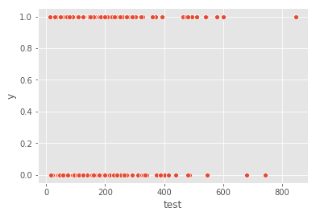

```python
sns.scatterplot(x=X_Var.test,y=Y_Var.y)
print('Range of insulin level Diabetic Women', X_Var.test[Y_Var.y==1].max()-X_Var.test[Y_Var.y==1].min())
print('Range of insulin level Non Diabetic Women', X_Var.test[Y_Var.y==0].max()-X_Var.test[Y_Var.y==0].min())
```

```
Range of BMI Diabetic Women 44.199999999999996
Range of BMI Non Diabetic Women 39.099999999999994
```

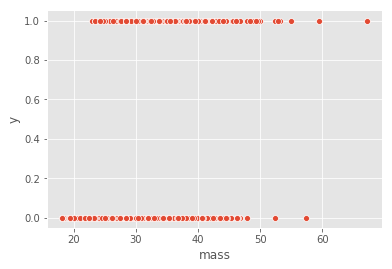

```python
sns.scatterplot(x=X_Var.mass,y=Y_Var.y)
print('Range of BMI Diabetic Women', X_Var.mass[Y_Var.y==1].max()-X_Var.mass[Y_Var.y==1].min())
print('Range of BMI Non Diabetic Women', X_Var.mass[Y_Var.y==0].max()-X_Var.mass[Y_Var.y==0].min())
```

```
Range of pedi Diabetic Women 1.1119999999999999
Range of pedi Non Diabetic Women 1.1219999999999999
```

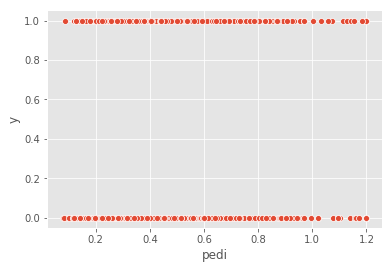

```python
sns.scatterplot(x=X_Var.pedi,y=Y_Var.y)
print('Range of pedi Diabetic Women', X_Var.pedi[Y_Var.y==1].max()-X_Var.pedi[Y_Var.y==1].min())
print('Range of pedi Non Diabetic Women', X_Var.pedi[Y_Var.y==0].max()-X_Var.pedi[Y_Var.y==0].min())
```

```
Range of Age Diabetic Women 45.5
Range of Age Non Diabetic Women 45.5
```

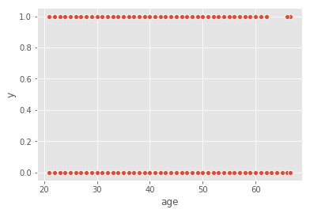

```python
sns.scatterplot(x=X_Var.age,y=Y_Var.y)
print('Range of Age Diabetic Women', X_Var.age[Y_Var.y==1].max()-X_Var.age[Y_Var.y==1].min())
print('Range of Age Non Diabetic Women', X_Var.age[Y_Var.y==0].max()-X_Var.age[Y_Var.y==0].min())
```

```python
count_no_diabetic=len(data_final.y[data_final.y==0])
count_diabetic=len(data_final.y[data_final.y==1])
pct_no_diabetic=count_no_diabetic/(count_no_diabetic+count_diabetic)
print("percentage of no diabetic women is : ", pct_no_diabetic*100)
pct_diabetic=count_diabetic/(count_no_diabetic+count_diabetic)
print("percentage of diabetic women is : ", pct_diabetic*100)
```

```
percentage of no diabetic women is :  65.10416666666666
percentage of diabetic women is :  34.89583333333333
```

```python
D_Final=pd.concat([X_Var,Y_Var],axis=1)
```

```python
def relation(x,y):
    print("Relation Between {}".format(x.name),"& {}".format(y.name),'{}'.format(sns.scatterplot(x,y)))
```

```
Relation Between Preg & Plas AxesSubplot(0.125,0.125;0.775x0.755)
```

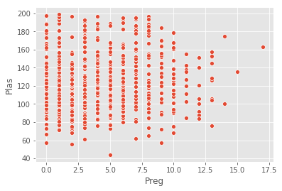

```python
relation(D_Final.Preg,D_Final.Plas)
```

```
Relation Between Pres & Plas AxesSubplot(0.125,0.125;0.775x0.755)
```

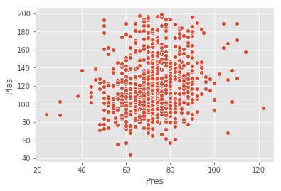

```python
relation(D_Final.Pres,D_Final.Plas)
```

```
Relation Between skin & Plas AxesSubplot(0.125,0.125;0.775x0.755)
```

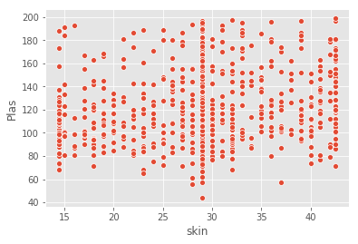

```python
relation(D_Final.skin,D_Final.Plas)
```

```
Relation Between test & Plas AxesSubplot(0.125,0.125;0.775x0.755)
```

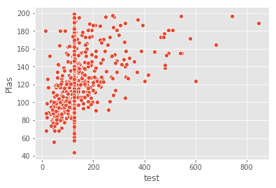

```python
relation(D_Final.test,D_Final.Plas)
```

```
Relation Between mass & Plas AxesSubplot(0.125,0.125;0.775x0.755)
```

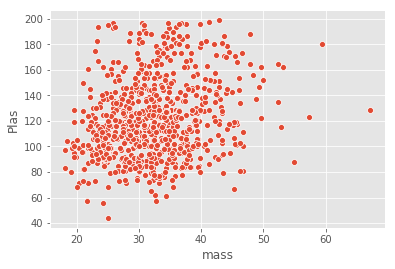

```python
relation(D_Final.mass,D_Final.Plas)
```

```python
D_Final.dtypes
```

```
Preg      int64
Plas      int64
Pres      int64
skin    float64
test      int64
mass    float64
pedi    float64
age     float64
y         int64
dtype: object
```

```python
preg_val=D_Final.Preg.unique()
preg_val.sort()
def range_preg(x):
    for val in preg_val:
        print("Range of {}".format(x),"for {}".format(val),"Pregnancy is {}".format(D_Final[x][D_Final.Preg==val].max()-D_Final[x][D_Final.Preg==val].min()))
        print("Mean of {}".format(x),"for {}".format(val),"Pregnancy is {}".format(D_Final[x][D_Final.Preg==val].mean()))
        print("Range of {}".format(x),"for {}".format(val),"Pregnancy and is Diabetic is {}".format(D_Final[x][(D_Final.Preg==val)&(D_Final.y==1)].max()-D_Final[x][(D_Final.Preg==val)&(D_Final.y==1)].min()))
        print("Range of {}".format(x),"for {}".format(val),"Pregnancy and is Non-Diabetic is {}".format(D_Final[x][(D_Final.Preg==val)&(D_Final.y==0)].max()-D_Final[x][(D_Final.Preg==val)&(D_Final.y==0)].min()))
```

```python
range_preg('Plas')
```

```
Range of Plas for 0 Pregnancy is 141
Mean of Plas for 0 Pregnancy is 123.0
Range of Plas for 0 Pregnancy and is Diabetic is 103
Range of Plas for 0 Pregnancy and is Non-Diabetic is 116
Range of Plas for 1 Pregnancy is 128
Mean of Plas for 1 Pregnancy is 115.34814814814816
Range of Plas for 1 Pregnancy and is Diabetic is 111
Range of Plas for 1 Pregnancy and is Non-Diabetic is 122
Range of Plas for 2 Pregnancy is 141
Mean of Plas for 2 Pregnancy is 110.79611650485437
Range of Plas for 2 Pregnancy and is Diabetic is 107
Range of Plas for 2 Pregnancy and is Non-Diabetic is 119
Range of Plas for 3 Pregnancy is 132
Mean of Plas for 3 Pregnancy is 123.58666666666667
Range of Plas for 3 Pregnancy and is Diabetic is 115
Range of Plas for 3 Pregnancy and is Non-Diabetic is 130
Range of Plas for 4 Pregnancy is 121
Mean of Plas for 4 Pregnancy is 125.11764705882354
Range of Plas for 4 Pregnancy and is Diabetic is 89
Range of Plas for 4 Pregnancy and is Non-Diabetic is 121
Range of Plas for 5 Pregnancy is 145
Mean of Plas for 5 Pregnancy is 120.91228070175438
Range of Plas for 5 Pregnancy and is Diabetic is 104
Range of Plas for 5 Pregnancy and is Non-Diabetic is 114
Range of Plas for 6 Pregnancy is 115
Mean of Plas for 6 Pregnancy is 123.14
Range of Plas for 6 Pregnancy and is Diabetic is 93
Range of Plas for 6 Pregnancy and is Non-Diabetic is 103
Range of Plas for 7 Pregnancy is 134
Mean of Plas for 7 Pregnancy is 136.44444444444446
Range of Plas for 7 Pregnancy and is Diabetic is 99
Range of Plas for 7 Pregnancy and is Non-Diabetic is 117
Range of Plas for 8 Pregnancy is 132
Mean of Plas for 8 Pregnancy is 131.73684210526315
Range of Plas for 8 Pregnancy and is Diabetic is 97
Range of Plas for 8 Pregnancy and is Non-Diabetic is 129
Range of Plas for 9 Pregnancy is 127
Mean of Plas for 9 Pregnancy is 131.39285714285714
Range of Plas for 9 Pregnancy and is Diabetic is 82
Range of Plas for 9 Pregnancy and is Non-Diabetic is 97
```

[output cut: 13 more lines]

```
Mean of Plas for 13 Pregnancy is 125.5
Range of Plas for 13 Pregnancy and is Diabetic is 54
Range of Plas for 13 Pregnancy and is Non-Diabetic is 77
Range of Plas for 14 Pregnancy is 75
Mean of Plas for 14 Pregnancy is 137.5
Range of Plas for 14 Pregnancy and is Diabetic is 75
Range of Plas for 14 Pregnancy and is Non-Diabetic is nan
Range of Plas for 15 Pregnancy is 0
Mean of Plas for 15 Pregnancy is 136.0
Range of Plas for 15 Pregnancy and is Diabetic is 0
Range of Plas for 15 Pregnancy and is Non-Diabetic is nan
Range of Plas for 17 Pregnancy is 0
Mean of Plas for 17 Pregnancy is 163.0
Range of Plas for 17 Pregnancy and is Diabetic is 0
Range of Plas for 17 Pregnancy and is Non-Diabetic is nan
```

```python
range_preg('Pres')
```

```
Range of Pres for 0 Pregnancy is 70
Range of Pres for 0 Pregnancy and is Diabetic is 70
Range of Pres for 0 Pregnancy and is Non-Diabetic is 50
Range of Pres for 1 Pregnancy is 98
Range of Pres for 1 Pregnancy and is Diabetic is 72
Range of Pres for 1 Pregnancy and is Non-Diabetic is 98
Range of Pres for 2 Pregnancy is 50
Range of Pres for 2 Pregnancy and is Diabetic is 38
Range of Pres for 2 Pregnancy and is Non-Diabetic is 50
Range of Pres for 3 Pregnancy is 56
Range of Pres for 3 Pregnancy and is Diabetic is 42
Range of Pres for 3 Pregnancy and is Non-Diabetic is 56
Range of Pres for 4 Pregnancy is 54
Range of Pres for 4 Pregnancy and is Diabetic is 32
Range of Pres for 4 Pregnancy and is Non-Diabetic is 54
Range of Pres for 5 Pregnancy is 60
Range of Pres for 5 Pregnancy and is Diabetic is 46
Range of Pres for 5 Pregnancy and is Non-Diabetic is 60
Range of Pres for 6 Pregnancy is 52
Range of Pres for 6 Pregnancy and is Diabetic is 42
Range of Pres for 6 Pregnancy and is Non-Diabetic is 52
Range of Pres for 7 Pregnancy is 45
Range of Pres for 7 Pregnancy and is Diabetic is 40
Range of Pres for 7 Pregnancy and is Non-Diabetic is 35
Range of Pres for 8 Pregnancy is 51
Range of Pres for 8 Pregnancy and is Diabetic is 44
Range of Pres for 8 Pregnancy and is Non-Diabetic is 33
Range of Pres for 9 Pregnancy is 58
Range of Pres for 9 Pregnancy and is Diabetic is 54
Range of Pres for 9 Pregnancy and is Non-Diabetic is 28
Range of Pres for 10 Pregnancy is 44
Range of Pres for 10 Pregnancy and is Diabetic is 24
Range of Pres for 10 Pregnancy and is Non-Diabetic is 44
Range of Pres for 11 Pregnancy is 38
Range of Pres for 11 Pregnancy and is Diabetic is 22
Range of Pres for 11 Pregnancy and is Non-Diabetic is 38
Range of Pres for 12 Pregnancy is 23
Range of Pres for 12 Pregnancy and is Diabetic is 20
Range of Pres for 12 Pregnancy and is Non-Diabetic is 11
Range of Pres for 13 Pregnancy is 54
Range of Pres for 13 Pregnancy and is Diabetic is 42
Range of Pres for 13 Pregnancy and is Non-Diabetic is 28
Range of Pres for 14 Pregnancy is 16
Range of Pres for 14 Pregnancy and is Diabetic is 16
Range of Pres for 14 Pregnancy and is Non-Diabetic is nan
Range of Pres for 15 Pregnancy is 0
Range of Pres for 15 Pregnancy and is Diabetic is 0
Range of Pres for 15 Pregnancy and is Non-Diabetic is nan
Range of Pres for 17 Pregnancy is 0
Range of Pres for 17 Pregnancy and is Diabetic is 0
Range of Pres for 17 Pregnancy and is Non-Diabetic is nan
```

There is no direct relation between pregnancy and blood pressure, hence their range also fluctuates with number of pregnancy

```python
range_preg('skin')
```

```
Range of skin for 0 Pregnancy is 28.0
Range of skin for 0 Pregnancy and is Diabetic is 28.0
Range of skin for 0 Pregnancy and is Non-Diabetic is 28.0
Range of skin for 1 Pregnancy is 28.0
Range of skin for 1 Pregnancy and is Diabetic is 25.5
Range of skin for 1 Pregnancy and is Non-Diabetic is 28.0
Range of skin for 2 Pregnancy is 28.0
Range of skin for 2 Pregnancy and is Diabetic is 25.5
Range of skin for 2 Pregnancy and is Non-Diabetic is 28.0
Range of skin for 3 Pregnancy is 28.0
Range of skin for 3 Pregnancy and is Diabetic is 28.0
Range of skin for 3 Pregnancy and is Non-Diabetic is 26.5
Range of skin for 4 Pregnancy is 28.0
Range of skin for 4 Pregnancy and is Diabetic is 28.0
Range of skin for 4 Pregnancy and is Non-Diabetic is 28.0
Range of skin for 5 Pregnancy is 24.5
Range of skin for 5 Pregnancy and is Diabetic is 22.0
Range of skin for 5 Pregnancy and is Non-Diabetic is 24.5
Range of skin for 6 Pregnancy is 28.0
Range of skin for 6 Pregnancy and is Diabetic is 23.0
Range of skin for 6 Pregnancy and is Non-Diabetic is 28.0
Range of skin for 7 Pregnancy is 27.5
Range of skin for 7 Pregnancy and is Diabetic is 21.5
Range of skin for 7 Pregnancy and is Non-Diabetic is 27.0
Range of skin for 8 Pregnancy is 23.5
Range of skin for 8 Pregnancy and is Diabetic is 18.5
Range of skin for 8 Pregnancy and is Non-Diabetic is 21.0
Range of skin for 9 Pregnancy is 27.5
Range of skin for 9 Pregnancy and is Diabetic is 27.5
Range of skin for 9 Pregnancy and is Non-Diabetic is 20.5
Range of skin for 10 Pregnancy is 24.5
Range of skin for 10 Pregnancy and is Diabetic is 19.5
Range of skin for 10 Pregnancy and is Non-Diabetic is 24.5
Range of skin for 11 Pregnancy is 14.0
Range of skin for 11 Pregnancy and is Diabetic is 14.0
Range of skin for 11 Pregnancy and is Non-Diabetic is 11.0
Range of skin for 12 Pregnancy is 28.0
Range of skin for 12 Pregnancy and is Diabetic is 28.0
Range of skin for 12 Pregnancy and is Non-Diabetic is 23.0
Range of skin for 13 Pregnancy is 23.5
Range of skin for 13 Pregnancy and is Diabetic is 4.0
Range of skin for 13 Pregnancy and is Non-Diabetic is 23.5
Range of skin for 14 Pregnancy is 5.0
Range of skin for 14 Pregnancy and is Diabetic is 5.0
Range of skin for 14 Pregnancy and is Non-Diabetic is nan
Range of skin for 15 Pregnancy is 0.0
Range of skin for 15 Pregnancy and is Diabetic is 0.0
Range of skin for 15 Pregnancy and is Non-Diabetic is nan
Range of skin for 17 Pregnancy is 0.0
Range of skin for 17 Pregnancy and is Diabetic is 0.0
Range of skin for 17 Pregnancy and is Non-Diabetic is nan
```

```python
range_preg('test')
```

```
Range of test for 0 Pregnancy is 666
Range of test for 0 Pregnancy and is Diabetic is 496
Range of test for 0 Pregnancy and is Non-Diabetic is 644
Range of test for 1 Pregnancy is 828
Range of test for 1 Pregnancy and is Diabetic is 788
Range of test for 1 Pregnancy and is Non-Diabetic is 467
Range of test for 2 Pregnancy is 528
Range of test for 2 Pregnancy and is Diabetic is 453
Range of test for 2 Pregnancy and is Non-Diabetic is 425
Range of test for 3 Pregnancy is 456
Range of test for 3 Pregnancy and is Diabetic is 426
Range of test for 3 Pregnancy and is Non-Diabetic is 369
Range of test for 4 Pregnancy is 695
Range of test for 4 Pregnancy and is Diabetic is 219
Range of test for 4 Pregnancy and is Non-Diabetic is 695
Range of test for 5 Pregnancy is 523
Range of test for 5 Pregnancy and is Diabetic is 237
Range of test for 5 Pregnancy and is Non-Diabetic is 523
Range of test for 6 Pregnancy is 316
Range of test for 6 Pregnancy and is Diabetic is 245
Range of test for 6 Pregnancy and is Non-Diabetic is 272
Range of test for 7 Pregnancy is 432
Range of test for 7 Pregnancy and is Diabetic is 389
Range of test for 7 Pregnancy and is Non-Diabetic is 294
Range of test for 8 Pregnancy is 551
Range of test for 8 Pregnancy and is Diabetic is 486
Range of test for 8 Pregnancy and is Non-Diabetic is 76
Range of test for 9 Pregnancy is 346
Range of test for 9 Pregnancy and is Diabetic is 115
Range of test for 9 Pregnancy and is Non-Diabetic is 346
Range of test for 10 Pregnancy is 188
Range of test for 10 Pregnancy and is Diabetic is 122
Range of test for 10 Pregnancy and is Non-Diabetic is 131
Range of test for 11 Pregnancy is 25
Range of test for 11 Pregnancy and is Diabetic is 25
Range of test for 11 Pregnancy and is Non-Diabetic is 0
Range of test for 12 Pregnancy is 271
Range of test for 12 Pregnancy and is Diabetic is 200
Range of test for 12 Pregnancy and is Non-Diabetic is 71
Range of test for 13 Pregnancy is 111
Range of test for 13 Pregnancy and is Diabetic is 96
Range of test for 13 Pregnancy and is Non-Diabetic is 30
Range of test for 14 Pregnancy is 59
Range of test for 14 Pregnancy and is Diabetic is 59
Range of test for 14 Pregnancy and is Non-Diabetic is nan
Range of test for 15 Pregnancy is 0
Range of test for 15 Pregnancy and is Diabetic is 0
Range of test for 15 Pregnancy and is Non-Diabetic is nan
Range of test for 17 Pregnancy is 0
Range of test for 17 Pregnancy and is Diabetic is 0
Range of test for 17 Pregnancy and is Non-Diabetic is nan
```

```python
range_preg('mass')
```

```
Range of mass for 0 Pregnancy is 48.699999999999996
Range of mass for 0 Pregnancy and is Diabetic is 39.699999999999996
Range of mass for 0 Pregnancy and is Non-Diabetic is 33.9
Range of mass for 1 Pregnancy is 36.8
Range of mass for 1 Pregnancy and is Diabetic is 31.6
Range of mass for 1 Pregnancy and is Non-Diabetic is 28.099999999999998
Range of mass for 2 Pregnancy is 25.9
Range of mass for 2 Pregnancy and is Diabetic is 18.9
Range of mass for 2 Pregnancy and is Non-Diabetic is 23.1
Range of mass for 3 Pregnancy is 38.0
Range of mass for 3 Pregnancy and is Diabetic is 15.5
Range of mass for 3 Pregnancy and is Non-Diabetic is 38.0
Range of mass for 4 Pregnancy is 27.499999999999996
Range of mass for 4 Pregnancy and is Diabetic is 24.499999999999996
Range of mass for 4 Pregnancy and is Non-Diabetic is 23.7
Range of mass for 5 Pregnancy is 29.0
Range of mass for 5 Pregnancy and is Diabetic is 27.099999999999998
Range of mass for 5 Pregnancy and is Non-Diabetic is 21.1
Range of mass for 6 Pregnancy is 26.6
Range of mass for 6 Pregnancy and is Diabetic is 22.700000000000003
Range of mass for 6 Pregnancy and is Non-Diabetic is 26.5
Range of mass for 7 Pregnancy is 27.3
Range of mass for 7 Pregnancy and is Diabetic is 24.9
Range of mass for 7 Pregnancy and is Non-Diabetic is 24.000000000000004
Range of mass for 8 Pregnancy is 24.799999999999997
Range of mass for 8 Pregnancy and is Diabetic is 24.599999999999998
Range of mass for 8 Pregnancy and is Non-Diabetic is 15.600000000000001
Range of mass for 9 Pregnancy is 24.599999999999998
Range of mass for 9 Pregnancy and is Diabetic is 20.599999999999998
Range of mass for 9 Pregnancy and is Non-Diabetic is 14.599999999999998
Range of mass for 10 Pregnancy is 22.5
Range of mass for 10 Pregnancy and is Diabetic is 20.1
Range of mass for 10 Pregnancy and is Non-Diabetic is 12.799999999999997
Range of mass for 11 Pregnancy is 23.999999999999996
Range of mass for 11 Pregnancy and is Diabetic is 23.999999999999996
Range of mass for 11 Pregnancy and is Non-Diabetic is 16.1
Range of mass for 12 Pregnancy is 18.199999999999996
Range of mass for 12 Pregnancy and is Diabetic is 14.199999999999996
Range of mass for 12 Pregnancy and is Non-Diabetic is 13.799999999999997
Range of mass for 13 Pregnancy is 21.2
Range of mass for 13 Pregnancy and is Diabetic is 16.599999999999998
Range of mass for 13 Pregnancy and is Non-Diabetic is 18.400000000000002
Range of mass for 14 Pregnancy is 3.0
Range of mass for 14 Pregnancy and is Diabetic is 3.0
Range of mass for 14 Pregnancy and is Non-Diabetic is nan
Range of mass for 15 Pregnancy is 0.0
Range of mass for 15 Pregnancy and is Diabetic is 0.0
Range of mass for 15 Pregnancy and is Non-Diabetic is nan
Range of mass for 17 Pregnancy is 0.0
Range of mass for 17 Pregnancy and is Diabetic is 0.0
Range of mass for 17 Pregnancy and is Non-Diabetic is nan
```

As the number of pregnancy increases spectrum of range of BMI decreases , and if we notice in most cases of pregnancies Diabetic spectrum of range of BMI is greater than then of non diabetic . There are only very few cases where non diabetic has a broader spectrum than diabetic , which can be because of other reason , as in women tend to gain weight in their pregnancies and hence increase in number of pregnancy increases their BMI .

```python
range_preg('pedi')
```

```
Range of pedi for 0 Pregnancy is 1.1219999999999999
Range of pedi for 0 Pregnancy and is Diabetic is 1.059
Range of pedi for 0 Pregnancy and is Non-Diabetic is 1.1219999999999999
Range of pedi for 1 Pregnancy is 1.1119999999999999
Range of pedi for 1 Pregnancy and is Diabetic is 1.1119999999999999
Range of pedi for 1 Pregnancy and is Non-Diabetic is 1.0999999999999999
Range of pedi for 2 Pregnancy is 1.115
Range of pedi for 2 Pregnancy and is Diabetic is 1.073
Range of pedi for 2 Pregnancy and is Non-Diabetic is 1.115
Range of pedi for 3 Pregnancy is 1.093
Range of pedi for 3 Pregnancy and is Diabetic is 1.073
Range of pedi for 3 Pregnancy and is Non-Diabetic is 0.8420000000000001
Range of pedi for 4 Pregnancy is 1.0819999999999999
Range of pedi for 4 Pregnancy and is Diabetic is 1.05
Range of pedi for 4 Pregnancy and is Non-Diabetic is 1.0819999999999999
Range of pedi for 5 Pregnancy is 1.065
Range of pedi for 5 Pregnancy and is Diabetic is 1.065
Range of pedi for 5 Pregnancy and is Non-Diabetic is 0.853
Range of pedi for 6 Pregnancy is 1.1159999999999999
Range of pedi for 6 Pregnancy and is Diabetic is 1.079
Range of pedi for 6 Pregnancy and is Non-Diabetic is 1.1159999999999999
Range of pedi for 7 Pregnancy is 0.999
Range of pedi for 7 Pregnancy and is Diabetic is 0.999
Range of pedi for 7 Pregnancy and is Non-Diabetic is 0.606
Range of pedi for 8 Pregnancy is 1.071
Range of pedi for 8 Pregnancy and is Diabetic is 1.0619999999999998
Range of pedi for 8 Pregnancy and is Non-Diabetic is 1.064
Range of pedi for 9 Pregnancy is 1.1039999999999999
Range of pedi for 9 Pregnancy and is Diabetic is 1.052
Range of pedi for 9 Pregnancy and is Non-Diabetic is 0.637
Range of pedi for 10 Pregnancy is 1.0659999999999998
Range of pedi for 10 Pregnancy and is Diabetic is 0.9949999999999999
Range of pedi for 10 Pregnancy and is Non-Diabetic is 1.0659999999999998
Range of pedi for 11 Pregnancy is 1.0739999999999998
Range of pedi for 11 Pregnancy and is Diabetic is 0.946
Range of pedi for 11 Pregnancy and is Non-Diabetic is 0.294
Range of pedi for 12 Pregnancy is 0.7889999999999999
Range of pedi for 12 Pregnancy and is Diabetic is 0.629
Range of pedi for 12 Pregnancy and is Non-Diabetic is 0.351
Range of pedi for 13 Pregnancy is 0.9960000000000001
Range of pedi for 13 Pregnancy and is Diabetic is 0.474
Range of pedi for 13 Pregnancy and is Non-Diabetic is 0.9960000000000001
Range of pedi for 14 Pregnancy is 0.20000000000000004
Range of pedi for 14 Pregnancy and is Diabetic is 0.20000000000000004
Range of pedi for 14 Pregnancy and is Non-Diabetic is nan
Range of pedi for 15 Pregnancy is 0.0
Range of pedi for 15 Pregnancy and is Diabetic is 0.0
Range of pedi for 15 Pregnancy and is Non-Diabetic is nan
Range of pedi for 17 Pregnancy is 0.0
Range of pedi for 17 Pregnancy and is Diabetic is 0.0
Range of pedi for 17 Pregnancy and is Non-Diabetic is nan
```

```python
range_preg('age')
```

```
Range of age for 0 Pregnancy is 45.5
Range of age for 0 Pregnancy and is Diabetic is 41.0
Range of age for 0 Pregnancy and is Non-Diabetic is 45.5
Range of age for 1 Pregnancy is 41.0
Range of age for 1 Pregnancy and is Diabetic is 38.0
Range of age for 1 Pregnancy and is Non-Diabetic is 41.0
Range of age for 2 Pregnancy is 45.5
Range of age for 2 Pregnancy and is Diabetic is 45.0
Range of age for 2 Pregnancy and is Non-Diabetic is 45.5
Range of age for 3 Pregnancy is 42.0
Range of age for 3 Pregnancy and is Diabetic is 30.0
Range of age for 3 Pregnancy and is Non-Diabetic is 42.0
Range of age for 4 Pregnancy is 45.5
Range of age for 4 Pregnancy and is Diabetic is 44.5
Range of age for 4 Pregnancy and is Non-Diabetic is 42.0
Range of age for 5 Pregnancy is 42.5
Range of age for 5 Pregnancy and is Diabetic is 33.0
Range of age for 5 Pregnancy and is Non-Diabetic is 42.5
Range of age for 6 Pregnancy is 43.0
Range of age for 6 Pregnancy and is Diabetic is 37.0
Range of age for 6 Pregnancy and is Non-Diabetic is 43.0
Range of age for 7 Pregnancy is 37.0
Range of age for 7 Pregnancy and is Diabetic is 26.0
Range of age for 7 Pregnancy and is Non-Diabetic is 37.0
Range of age for 8 Pregnancy is 44.5
Range of age for 8 Pregnancy and is Diabetic is 38.0
Range of age for 8 Pregnancy and is Non-Diabetic is 32.5
Range of age for 9 Pregnancy is 37.5
Range of age for 9 Pregnancy and is Diabetic is 25.0
Range of age for 9 Pregnancy and is Non-Diabetic is 33.5
Range of age for 10 Pregnancy is 34.0
Range of age for 10 Pregnancy and is Diabetic is 26.0
Range of age for 10 Pregnancy and is Non-Diabetic is 34.0
Range of age for 11 Pregnancy is 16.0
Range of age for 11 Pregnancy and is Diabetic is 11.0
Range of age for 11 Pregnancy and is Non-Diabetic is 16.0
Range of age for 12 Pregnancy is 24.0
Range of age for 12 Pregnancy and is Diabetic is 20.0
Range of age for 12 Pregnancy and is Non-Diabetic is 21.0
Range of age for 13 Pregnancy is 19.0
Range of age for 13 Pregnancy and is Diabetic is 6.0
Range of age for 13 Pregnancy and is Non-Diabetic is 18.0
Range of age for 14 Pregnancy is 8.0
Range of age for 14 Pregnancy and is Diabetic is 8.0
Range of age for 14 Pregnancy and is Non-Diabetic is nan
Range of age for 15 Pregnancy is 0.0
Range of age for 15 Pregnancy and is Diabetic is 0.0
Range of age for 15 Pregnancy and is Non-Diabetic is nan
Range of age for 17 Pregnancy is 0.0
Range of age for 17 Pregnancy and is Diabetic is 0.0
Range of age for 17 Pregnancy and is Non-Diabetic is nan
```

spectrum of range of age with increase in number of pregnancy we see that the spectrum of non diabetic is greater than diabetic

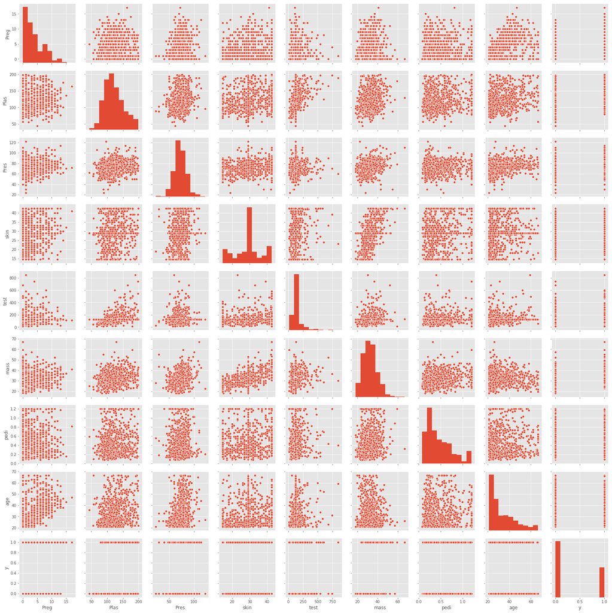

```python
sns.pairplot(D_Final)
```

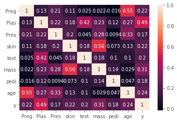

```python
sns.heatmap(D_Final.corr(),annot=True)
```

# **Logistic Regression**

```python
logreg = LogisticRegression()

rfe = RFE(logreg, 18)
rfe = rfe.fit(X_Var, Y_Var )
print(rfe.support_)
print(rfe.ranking_)
```

```
[ True  True  True  True  True  True  True  True]
[1 1 1 1 1 1 1 1]
```

```python
col=X_Var.columns[rfe.support_==True]
```

```python
x_final=D_Final[col]
```

```python
y=D_Final[['y']]
```

```python
y.y=y.y.astype('int64')
```

```python
import statsmodels.api as sm
logit_model=sm.Logit(y['y'],x_final)
```

```python
X=x_final.columns[0:6]
```

```python
X
```

```
Index(['Preg', 'Plas', 'Pres', 'skin', 'test', 'mass'], dtype='object')
```

```python
X1=X.drop('test')
```

```python
X2=X1.drop('skin')
```

```python
result=logit_model.fit()
```

```
Optimization terminated successfully.
         Current function value: 0.575317
         Iterations 5
```

```python
result.summary2()
```

| Model: | Logit | Pseudo R-squared: | 0.111 |
| --- | --- | --- | --- |
| Dependent Variable: | y | AIC: | 899.6877 |
| Date: | 2019-04-13 14:12 | BIC: | 936.8380 |
| No. Observations: | 768 | Log-Likelihood: | -441.84 |
| Df Model: | 7 | LL-Null: | -496.74 |
| Df Residuals: | 760 | LLR p-value: | 1.0121e-20 |
| Converged: | 1.0000 | Scale: | 1.0000 |
| No. Iterations: | 5.0000 |  |  |

|  | Coef. | Std.Err. | z | P>\|z\| | [0.025 | 0.975] |
| --- | --- | --- | --- | --- | --- | --- |
| Preg | 0.1355 | 0.0296 | 4.5833 | 0.0000 | 0.0776 | 0.1935 |
| Plas | 0.0228 | 0.0032 | 7.0820 | 0.0000 | 0.0165 | 0.0290 |
| Pres | -0.0595 | 0.0071 | -8.4183 | 0.0000 | -0.0733 | -0.0456 |
| skin | -0.0218 | 0.0133 | -1.6417 | 0.1007 | -0.0479 | 0.0042 |
| test | -0.0004 | 0.0010 | -0.3413 | 0.7329 | -0.0024 | 0.0017 |
| mass | 0.0284 | 0.0151 | 1.8798 | 0.0601 | -0.0012 | 0.0580 |
| pedi | 0.4908 | 0.2854 | 1.7199 | 0.0855 | -0.0685 | 1.0502 |
| age | -0.0014 | 0.0090 | -0.1552 | 0.8767 | -0.0190 | 0.0162 |

```python
logit_model=sm.Logit(y['y'],x_final[X])
```

```python
result=logit_model.fit()
result.summary2()
```

```
Optimization terminated successfully.
         Current function value: 0.577244
         Iterations 5
```

| Model: | Logit | Pseudo R-squared: | 0.108 |
| --- | --- | --- | --- |
| Dependent Variable: | y | AIC: | 898.6468 |
| Date: | 2019-04-13 14:13 | BIC: | 926.5095 |
| No. Observations: | 768 | Log-Likelihood: | -443.32 |
| Df Model: | 5 | LL-Null: | -496.74 |
| Df Residuals: | 762 | LLR p-value: | 1.9083e-21 |
| Converged: | 1.0000 | Scale: | 1.0000 |
| No. Iterations: | 5.0000 |  |  |

|  | Coef. | Std.Err. | z | P>\|z\| | [0.025 | 0.975] |
| --- | --- | --- | --- | --- | --- | --- |
| Preg | 0.1316 | 0.0254 | 5.1835 | 0.0000 | 0.0818 | 0.1814 |
| Plas | 0.0230 | 0.0031 | 7.4080 | 0.0000 | 0.0169 | 0.0291 |
| Pres | -0.0591 | 0.0066 | -8.8963 | 0.0000 | -0.0721 | -0.0461 |
| skin | -0.0221 | 0.0132 | -1.6657 | 0.0958 | -0.0480 | 0.0039 |
| test | -0.0003 | 0.0010 | -0.2716 | 0.7860 | -0.0023 | 0.0017 |
| mass | 0.0323 | 0.0148 | 2.1789 | 0.0293 | 0.0033 | 0.0614 |

```python
logit_model=sm.Logit(y['y'],x_final[X1])
result=logit_model.fit()
result.summary2()
```

```
Optimization terminated successfully.
         Current function value: 0.577292
         Iterations 5
```

| Model: | Logit | Pseudo R-squared: | 0.107 |
| --- | --- | --- | --- |
| Dependent Variable: | y | AIC: | 896.7204 |
| Date: | 2019-04-13 14:14 | BIC: | 919.9393 |
| No. Observations: | 768 | Log-Likelihood: | -443.36 |
| Df Model: | 4 | LL-Null: | -496.74 |
| Df Residuals: | 763 | LLR p-value: | 3.5649e-22 |
| Converged: | 1.0000 | Scale: | 1.0000 |
| No. Iterations: | 5.0000 |  |  |

|  | Coef. | Std.Err. | z | P>\|z\| | [0.025 | 0.975] |
| --- | --- | --- | --- | --- | --- | --- |
| Preg | 0.1317 | 0.0254 | 5.1911 | 0.0000 | 0.0820 | 0.1815 |
| Plas | 0.0227 | 0.0029 | 7.8734 | 0.0000 | 0.0171 | 0.0284 |
| Pres | -0.0589 | 0.0066 | -8.9182 | 0.0000 | -0.0719 | -0.0460 |
| skin | -0.0223 | 0.0132 | -1.6932 | 0.0904 | -0.0482 | 0.0035 |
| mass | 0.0322 | 0.0148 | 2.1695 | 0.0300 | 0.0031 | 0.0612 |

```python
logit_model=sm.Logit(y['y'],x_final[X2])
result=logit_model.fit()
result.summary2()
```

```
Optimization terminated successfully.
         Current function value: 0.579168
         Iterations 5
```

| Model: | Logit | Pseudo R-squared: | 0.105 |
| --- | --- | --- | --- |
| Dependent Variable: | y | AIC: | 897.6016 |
| Date: | 2019-04-13 14:15 | BIC: | 916.1767 |
| No. Observations: | 768 | Log-Likelihood: | -444.80 |
| Df Model: | 3 | LL-Null: | -496.74 |
| Df Residuals: | 764 | LLR p-value: | 2.2728e-22 |
| Converged: | 1.0000 | Scale: | 1.0000 |
| No. Iterations: | 5.0000 |  |  |

|  | Coef. | Std.Err. | z | P>\|z\| | [0.025 | 0.975] |
| --- | --- | --- | --- | --- | --- | --- |
| Preg | 0.1265 | 0.0251 | 5.0476 | 0.0000 | 0.0774 | 0.1756 |
| Plas | 0.0223 | 0.0029 | 7.7580 | 0.0000 | 0.0166 | 0.0279 |
| Pres | -0.0601 | 0.0066 | -9.1508 | 0.0000 | -0.0730 | -0.0473 |
| mass | 0.0175 | 0.0120 | 1.4613 | 0.1439 | -0.0060 | 0.0411 |

```python
y=y[['y']]
x=x_final[X2]

seed = 2
test_size = 0.3
X_train, X_test, y_train, y_test = tts(x,y, test_size=test_size, random_state=seed)
```

```python
model=LogisticRegression(random_state=12)
model.fit(X_train,y_train)
```

```
LogisticRegression(C=1.0, class_weight=None, dual=False, fit_intercept=True,
          intercept_scaling=1, max_iter=100, multi_class='warn',
          n_jobs=None, penalty='l2', random_state=12, solver='warn',
          tol=0.0001, verbose=0, warm_start=False)
```

```python
def model(n):
    model=LogisticRegression(random_state=12)
    #rfe=RFE(model,n)
    #fit=rfe.fit(X_train,y_train)
    Logit=LogisticRegression
    #print("Num Features: %s" % (fit.n_features_))
    #print("Selected Features: %s" % (fit.support_))
    #print("Feature Ranking: %s" % (fit.ranking_))
    #s_colname=X_train.columns[fit.support_==True]
    xtrain=X_train
    xtest=X_test
    smote_pip=make_pipeline_imb(SMOTE(random_state=4,k_neighbors=4),Logit(random_state=42))
    smote_mod=smote_pip.fit(xtrain,y_train)
    smote_pred=pd.DataFrame(smote_mod.predict_proba(xtrain))
    smote_pred.columns=['Zero_Prob','One_Prob']
    fpr,tpr,thresholds=metrics.roc_curve(y_train.y,smote_pred.One_Prob)
    plt.xlim([0.0,1.0])
    plt.ylim([0.0,1.0])
    plt.title('ROC Curve')
    plt.xlabel('FPR')
    plt.ylabel('TPR')
    print(plt.plot(fpr,tpr))
    plt.grid(True)
    trh=[.1,.15,.2,.25,.3,.35,.4,.45,.5,.55,.56,.57,.6,.7,.8,.9]
    evalualte=pd.Series()
    def eval_threshold(threshold):
        print('Sensitivity:',tpr[thresholds>threshold][-1])
        print('Specificity:',1-fpr[thresholds>threshold][-1])
    for i in trh:
        print(i,'\n',evalualte.append(eval_threshold(i)))
    #return evalualte
```

```
Sensitivity: 1.0
Specificity: 0.14492753623188404
0.1
 Series([], dtype: float64)
Sensitivity: 0.9895833333333334
Specificity: 0.2376811594202899
0.15
 Series([], dtype: float64)
Sensitivity: 0.9791666666666666
Specificity: 0.30724637681159417
0.2
 Series([], dtype: float64)
Sensitivity: 0.9583333333333334
Specificity: 0.4057971014492754
0.25
 Series([], dtype: float64)
Sensitivity: 0.9322916666666666
Specificity: 0.5043478260869565
0.3
 Series([], dtype: float64)
Sensitivity: 0.8802083333333334
Specificity: 0.5652173913043479
0.35
 Series([], dtype: float64)
Sensitivity: 0.859375
Specificity: 0.6318840579710145
0.4
 Series([], dtype: float64)
Sensitivity: 0.8125
Specificity: 0.7072463768115942
0.45
 Series([], dtype: float64)
Sensitivity: 0.734375
Specificity: 0.7420289855072464
0.5
 Series([], dtype: float64)
Sensitivity: 0.6927083333333334
Specificity: 0.8144927536231884
0.55
 Series([], dtype: float64)
```

[output cut: 9 more lines]

```
Specificity: 0.855072463768116
0.6
 Series([], dtype: float64)
Sensitivity: 0.5208333333333334
Specificity: 0.9101449275362319
0.7
 Series([], dtype: float64)
Sensitivity: 0.3541666666666667
Specificity: 0.9594202898550724
0.8
 Series([], dtype: float64)
Sensitivity: 0.11979166666666667
Specificity: 0.991304347826087
0.9
 Series([], dtype: float64)
```

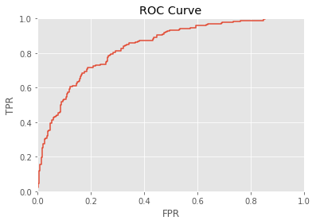

```python
model(10)
```

```python
Logit=LogisticRegression
smote_pip=make_pipeline_imb(SMOTE(random_state=4,k_neighbors=4),Logit(random_state=42))
smote_mod=smote_pip.fit(X_train,y_train)
smote_pred=pd.DataFrame(smote_mod.predict_proba(X_train))
smote_pred.columns=['Zero_Prob','One_Prob']
```

```python
pred_prob_tr=smote_pred[['One_Prob']]
```

```python
pred_prob_tr['pred']=0
pred_prob_tr.pred[pred_prob_tr.One_Prob>=.4]=1
pred_prob_tr.pred[pred_prob_tr.One_Prob<.4]=0
```

```python
print(confusion_matrix(y_train.y, pred_prob_tr.pred,[0,1]))
predictions = [value for value in pred_prob_tr.pred]
accuracy = accuracy_score(y_train.y, predictions)
precision = precision_score(y_train.y, predictions)
recall = recall_score(y_train.y, predictions)
f1 = f1_score(y_train.y, predictions)
print("Accuracy_score: %.2f%% on train dataset" % (accuracy * 100.0))
print("precision_score: %.2f%% on train dataset" % (precision * 100.0))
print("recall_score: %.2f%% on train dataset" % (recall * 100.0))
print("f1_score: %.2f%% on train dataset" % (f1 * 100.0))
#print("roc_auc test set", roc_auc_score(y_train, modelXg.predict_proba(X_train)[:,1]))
print("roc_auc training set", roc_auc_score(y_train.y, smote_mod.predict_proba(X_train)[:,1]))
```

```
[[218 127]
 [ 27 165]]
Accuracy_score: 71.32% on train dataset
precision_score: 56.51% on train dataset
recall_score: 85.94% on train dataset
f1_score: 68.18% on train dataset
roc_auc training set 0.8378019323671497
```

```python
smote_pred=pd.DataFrame(smote_mod.predict_proba(X_test))
smote_pred.columns=['Zero_Prob','One_Prob']
pred_prob_tr=smote_pred[['One_Prob']]
pred_prob_tr['pred']=0
pred_prob_tr.pred[pred_prob_tr.One_Prob>=.4]=1
pred_prob_tr.pred[pred_prob_tr.One_Prob<.4]=0
```

```python
print(confusion_matrix(y_test.y, pred_prob_tr.pred,[0,1]))
predictions = [value for value in pred_prob_tr.pred]
accuracy = accuracy_score(y_test.y, predictions)
precision = precision_score(y_test.y, predictions)
recall = recall_score(y_test.y, predictions)
f1 = f1_score(y_test.y, predictions)
print("Accuracy_score: %.2f%% on train dataset" % (accuracy * 100.0))
print("precision_score: %.2f%% on train dataset" % (precision * 100.0))
print("recall_score: %.2f%% on train dataset" % (recall * 100.0))
print("f1_score: %.2f%% on train dataset" % (f1 * 100.0))
#print("roc_auc test set", roc_auc_score(y_train, modelXg.predict_proba(X_train)[:,1]))
print("roc_auc training set", roc_auc_score(y_test.y, smote_mod.predict_proba(X_test)[:,1]))
```

```
[[102  53]
 [ 14  62]]
Accuracy_score: 71.00% on train dataset
precision_score: 53.91% on train dataset
recall_score: 81.58% on train dataset
f1_score: 64.92% on train dataset
roc_auc training set 0.7901528013582343
```

```python
y_train_pred=result.predict?
```

```python
y_train_pred=result.predict(x_final)
```

```python
print(confusion_matrix(y.y, y_train_pred,[0,1]))
predictions = [value for value in y_train_pred]
accuracy = accuracy_score(y.y, predictions)
precision = precision_score(y.y, predictions)
recall = recall_score(y.y, predictions)
f1 = f1_score(y.y, predictions)
print("Accuracy_score: %.2f%% on train dataset" % (accuracy * 100.0))
print("precision_score: %.2f%% on train dataset" % (precision * 100.0))
print("recall_score: %.2f%% on train dataset" % (recall * 100.0))
print("f1_score: %.2f%% on train dataset" % (f1 * 100.0))
#print("roc_auc test set", roc_auc_score(y_train, modelXg.predict_proba(X_train)[:,1]))
#print("roc_auc training set", roc_auc_score(y_train.Status, smote_mod.predict_proba(X_train)[:,1]))
```

[output not shown]

```python
D_Final.dtypes
```

```
Preg      int64
Plas      int64
Pres      int64
skin    float64
test      int64
mass    float64
pedi    float64
age     float64
y         int64
dtype: object
```

# **Naive Bayes**

```python
X=D_Final.iloc[:,0:8]
y=D_Final.iloc[:,8]
```

```python
sel = VarianceThreshold(threshold=(.8 * (1 - .8)))
X_filtered = sel.fit_transform(X)
```

```python
print(X.head(1))
print(X_filtered[0])
```

```
   Preg  Plas  Pres  skin  test  mass   pedi   age
0     6   148    72  35.0   125  33.6  0.627  50.0
[  6.  148.   72.   35.  125.   33.6  50. ]
```

```python
#Diabetese Pedigree Function Should be dropped as it has less variance
X = X.drop('pedi', axis=1)
```

[output not shown]

```python
top_4_features = SelectKBest(score_func=chi2, k=4)
X_top_4_features = top_4_features.fit_transform(X, y)
print(X.head())
#print(X_top_4_features)
```

```
   Preg  Plas  Pres  skin  test  mass   age
0     6   148    72  35.0   125  33.6  50.0
1     1    85    66  29.0   125  26.6  31.0
2     8   183    64  29.0   125  23.3  32.0
3     1    89    66  23.0    94  28.1  21.0
4     0   137    40  35.0   168  43.1  33.0
```

```python
X = X.drop(['Preg', 'Pres', 'skin'], axis=1)
```

```python
X_train, X_test, y_train, y_test = tts(X, y, random_state=0, test_size=0.20)
```

```python
sc_X = StandardScaler()
X_train = sc_X.fit_transform(X_train)
X_test = sc_X.transform(X_test)
```

```python
print("Training Data True Values   :{0} ".format(len(y_train[y_train==1])),(len(y_train[y_train==1])/len(y_train)))
print("Training Data False Values   :{0} ".format(len(y_train[y_train==0])),(len(y_train[y_train==0])/len(y_train)))
;
print("Test Data True Values   :{0} ".format(len(y_test[y_test==1])),(len(y_test[y_test==1])/len(y_test)))
print("Test Data False Values   :{0} ".format(len(y_test[y_test==0])),(len(y_test[y_test==0])/len(y_test)))
```

```
Training Data True Values   :221  0.35993485342019543
Training Data False Values   :393  0.6400651465798045
Test Data True Values   :47  0.3051948051948052
Test Data False Values   :107  0.6948051948051948
```

Ratio of Diabetic And Non-Diabetic looks fine

```python
classifier = GaussianNB()
classifier.fit(X_train, y_train.ravel())
```

```
GaussianNB(priors=None, var_smoothing=1e-09)
```

```python
def model(n):
    #model=LogisticRegression(random_state=12)
    #rfe=RFE(model,n)
    #fit=rfe.fit(X_train,y_train)
    #NB=GaussianNB
    #print("Num Features: %s" % (fit.n_features_))
    #print("Selected Features: %s" % (fit.support_))
    #print("Feature Ranking: %s" % (fit.ranking_))
    #s_colname=X_train.columns[fit.support_==True]
    xtrain=X_train
    xtest=X_test
    model_NB=GaussianNB()
    #smote_pip=make_pipeline_imb(SMOTE(random_state=4,k_neighbors=4),NB())
    NM_Mod=model_NB.fit(xtrain,y_train)
    #smote_mod=smote_pip.fit(xtrain,y_train)
    #smote_pred=pd.DataFrame(smote_mod.predict_proba(xtrain))
    smote_pred=pd.DataFrame(NM_Mod.predict_proba(xtrain))
    smote_pred.columns=['Zero_Prob','One_Prob']
    fpr,tpr,thresholds=metrics.roc_curve(y_train,smote_pred.One_Prob)
    plt.xlim([0.0,1.0])
    plt.ylim([0.0,1.0])
    plt.title('ROC Curve')
    plt.xlabel('FPR')
    plt.ylabel('TPR')
    print(plt.plot(fpr,tpr))
    plt.grid(True)
    trh=[.1,.15,.2,.25,.3,.35,.4,.45,.5,.55,.56,.57,.6,.7,.8,.9]
    evalualte=pd.Series()
    def eval_threshold(threshold):
        print('Sensitivity:',tpr[thresholds>threshold][-1])
        print('Specificity:',1-fpr[thresholds>threshold][-1])
    for i in trh:
        print(i,'\n',evalualte.append(eval_threshold(i)))
    #return evalualte
```

**Sensitivity Vs Specificity**

```
Sensitivity: 0.9366515837104072
Specificity: 0.46819338422391854
0.1
 Series([], dtype: float64)
Sensitivity: 0.8687782805429864
Specificity: 0.5725190839694656
0.15
 Series([], dtype: float64)
Sensitivity: 0.8190045248868778
Specificity: 0.6488549618320612
0.2
 Series([], dtype: float64)
Sensitivity: 0.751131221719457
Specificity: 0.7073791348600509
0.25
 Series([], dtype: float64)
Sensitivity: 0.665158371040724
Specificity: 0.7786259541984732
0.3
 Series([], dtype: float64)
Sensitivity: 0.6561085972850679
Specificity: 0.7989821882951654
0.35
 Series([], dtype: float64)
Sensitivity: 0.6289592760180995
Specificity: 0.8193384223918575
0.4
 Series([], dtype: float64)
Sensitivity: 0.583710407239819
Specificity: 0.8473282442748091
0.45
 Series([], dtype: float64)
Sensitivity: 0.5656108597285068
Specificity: 0.8702290076335878
0.5
 Series([], dtype: float64)
Sensitivity: 0.5339366515837104
Specificity: 0.8905852417302799
0.55
 Series([], dtype: float64)
```

[output cut: 9 more lines]

```
Specificity: 0.9007633587786259
0.6
 Series([], dtype: float64)
Sensitivity: 0.4072398190045249
Specificity: 0.9236641221374046
0.7
 Series([], dtype: float64)
Sensitivity: 0.334841628959276
Specificity: 0.9440203562340967
0.8
 Series([], dtype: float64)
Sensitivity: 0.2081447963800905
Specificity: 0.9592875318066157
0.9
 Series([], dtype: float64)
```

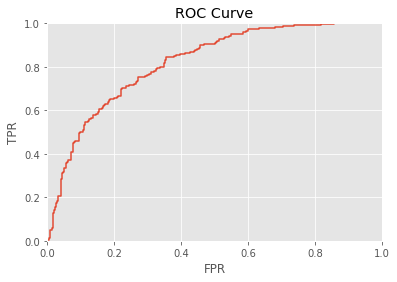

```python
model(1)
```

```python
y_pred_tr = pd.DataFrame(classifier.predict_proba(X_train))
```

```python
y_pred_tr.columns=['Prob_Zero','Prob_One']
```

```python
y_pred_tr['Pred']=0
y_pred_tr['Pred'][y_pred_tr.Prob_One>=.2]=1
y_pred_tr['Pred'][y_pred_tr.Prob_One<.2]=0
```

```python
print(confusion_matrix(y_train, y_pred_tr.Pred,[0,1]))
predictions = [value for value in y_pred_tr.Pred]
accuracy = accuracy_score(y_train, predictions)
precision = precision_score(y_train, predictions)
recall = recall_score(y_train, predictions)
f1 = f1_score(y_train, predictions)
print("Accuracy_score: %.2f%% on train dataset" % (accuracy * 100.0))
print("precision_score: %.2f%% on train dataset" % (precision * 100.0))
print("recall_score: %.2f%% on train dataset" % (recall * 100.0))
print("f1_score: %.2f%% on train dataset" % (f1 * 100.0))
#print("roc_auc test set", roc_auc_score(y_train, modelXg.predict_proba(X_train)[:,1]))
#print("roc_auc training set", roc_auc_score(y_train.Status, smote_mod.predict_proba(X_train)[:,1]))
```

```
[[255 138]
 [ 38 183]]
Accuracy_score: 71.34% on train dataset
precision_score: 57.01% on train dataset
recall_score: 82.81% on train dataset
f1_score: 67.53% on train dataset
```

```python
print(metrics.classification_report(y_train,y_pred_tr.Pred,labels=[1,0]))
```

```
              precision    recall  f1-score   support

           1       0.57      0.83      0.68       221
           0       0.87      0.65      0.74       393

   micro avg       0.71      0.71      0.71       614
   macro avg       0.72      0.74      0.71       614
weighted avg       0.76      0.71      0.72       614
```

```python
y_pred_te = pd.DataFrame(classifier.predict_proba(X_test))
y_pred_te.columns=['Prob_Zero','Prob_One']
y_pred_te['Pred']=0
y_pred_te['Pred'][y_pred_te.Prob_One>=.2]=1
y_pred_te['Pred'][y_pred_te.Prob_One<.2]=0
```

```python
print(confusion_matrix(y_test, y_pred_te.Pred,[0,1]))
predictions = [value for value in y_pred_te.Pred]
accuracy = accuracy_score(y_test, predictions)
precision = precision_score(y_test, predictions)
recall = recall_score(y_test, predictions)
f1 = f1_score(y_test, predictions)
print("Accuracy_score: %.2f%% on train dataset" % (accuracy * 100.0))
print("precision_score: %.2f%% on train dataset" % (precision * 100.0))
print("recall_score: %.2f%% on train dataset" % (recall * 100.0))
print("f1_score: %.2f%% on train dataset" % (f1 * 100.0))
#print("roc_auc test set", roc_auc_score(y_train, modelXg.predict_proba(X_train)[:,1]))
#print("roc_auc training set", roc_auc_score(y_train.Status, smote_mod.predict_proba(X_train)[:,1]))
```

```
[[75 32]
 [11 36]]
Accuracy_score: 72.08% on train dataset
precision_score: 52.94% on train dataset
recall_score: 76.60% on train dataset
f1_score: 62.61% on train dataset
```

```python
print(metrics.classification_report(y_test,y_pred_te.Pred,labels=[1,0]))
```

```
              precision    recall  f1-score   support

           1       0.53      0.77      0.63        47
           0       0.87      0.70      0.78       107

   micro avg       0.72      0.72      0.72       154
   macro avg       0.70      0.73      0.70       154
weighted avg       0.77      0.72      0.73       154
```

We have taken .2 as threshold because we want our recall to be more than precision , i.e we want Diabetic to be classified as Diabetic , hence if you see above in Sensitivity Vs Specificity Section you can see at threshold of .2 sensitivity is more than specificity hence it means we can correctly classify those with diabeties as diabetic .

In health domain we have to be more accurate for predicting those with disease hence we have to make trade off between classifying close to accuracy for diabetic as diabetic

Hence there is a trade off between precision and recall where I have chosen recall over precision.

Model performs well on both training and testing set , hence we can say its fairly generalized model and it doesnt have any issues of over fitting or under fitting